# Magma Series: Tholeiitic, Calc-Alkaline, and Alkaline

Dr. Ahmad Redaa

19-10-2025

# What is a Magma Series?

**Definition:**  
> A **magma (igneous) series** is a group of rocks related by chemical evolution and crystallization trends from a common parent magma.

Different series reflect:  
- Source composition  
- Degree of partial melting  
- Crystallization path  
- Tectonic setting

**Major series:**  
1. **Tholeiitic** 2. **Calc-Alkaline** 3. **Alkaline**

# Chemical Basis of Magma Series

- Defined mainly by **FeO–MgO–Alkali (Na₂O + K₂O)** trends.
- Illustrated by the **AFM Diagram** (Irvine & Baragar, 1971).

**AFM Diagram Axes:**  
- A = Na₂O + K₂O (alkalis)  
- F = FeO + Fe₂O₃ (iron)  
- M = MgO (magnesium)

**Trend Differences:**  
- **Tholeiitic:** strong Fe enrichment  
- **Calc-Alkaline:** limited Fe enrichment, early Fe oxidation  
- **Alkaline:** high alkali enrichment (Na + K)

# 1. Tholeiitic Series

**Characteristics:**  
- Iron-rich trend on AFM diagram  
- Common in **mid-ocean ridges (MORB)** and **intraplate basalts**  
- Typically low Na₂O + K₂O  
- High Fe/Mg ratio during fractionation  
- Late-stage Fe–Ti oxide crystallization

**Typical Minerals:**  
- Plagioclase (calcic → sodic)  
- Clinopyroxene and orthopyroxene  
- Olivine (early)  
- Fe–Ti oxides (late)

**Tectonic Setting:**  
- Oceanic ridges  
- Intraplate basaltic provinces  
- Some continental flood basalts

# 2. Calc-Alkaline Series

**Characteristics:**  
- Moderate Fe enrichment (Fe oxidation to magnetite)  
- Higher Al₂O₃ and CaO; lower FeO than tholeiitic series  
- Common in **volcanic arcs (subduction zones)**  
- Typically **water-rich magmas** → early crystallization of amphibole and biotite

**Mineralogy:**  
- Plagioclase  
- Clinopyroxene  
- Amphibole, biotite  
- Magnetite (oxidized Fe)

**Tectonic Setting:**  
- **Convergent plate boundaries** (island arcs, continental arcs)

**Examples:**  
Andesitic volcanoes of the Andes, Japan, Cascades

# 3. Alkaline Series

**Characteristics:**  
- High **Na₂O + K₂O** and often high **TiO₂**  
- Fe enrichment less pronounced  
- Late-stage alkali feldspar and feldspathoid minerals (e.g., nepheline, leucite)  
- Derived from **low-degree partial melting** of mantle source

**Mineralogy:**  
- Alkali feldspar  
- Nepheline, leucite (in undersaturated varieties)  
- Clinopyroxene (Ti-rich)  
- Olivine (commonly present)

**Tectonic Setting:**  
- **Intraplate** or **rift-related** magmatism  
- Hot spots, continental rifts

**Examples:**  
Mount Kenya (East African Rift), Canary Islands, Ocean Island Basalts (OIB)

# Comparison Summary

| Feature | **Tholeiitic** | **Calc-Alkaline** | **Alkaline** |
| --- | --- | --- | --- |
| **SiO₂ (wt%)** | 45–60 | 55–70 | 40–60 |
| **Fe trend** | Strong Fe enrichment | Moderate Fe (oxidized early) | Variable |
| **Na₂O + K₂O** | Low | Moderate | High |
| **Water content** | Dry | Wet | Variable |
| **Oxygen fugacity (fO₂)** | Low (reducing) | High (oxidizing) | Low–moderate |
| **Tectonic setting** | Ocean ridges, intraplate | Subduction zones | Rifts, hot spots |
| **Key rocks** | Basalt, gabbro | Andesite, dacite | Trachyte, phonolite |
| **Example location** | Iceland, Hawaii | Andes, Japan | East African Rift |

# Geochemical Indicators

### **AFM Diagram Trends**

- **Tholeiitic:** FeO enrichment → MgO decrease
- **Calc-Alkaline:** Alkali rise early; Fe constant or decreases
- **Alkaline:** Alkalis dominate early, divergent trend

### **TAS Diagram (Total Alkalis vs. Silica)**

- Differentiates **subalkaline (Tholeiitic + Calc-Alkaline)** from **alkaline** series.
- Boundary line by Irvine & Baragar (1971).

**AFM Diagram**  
> A ternary diagram showing chemical evolution of igneous rocks based on **A = (Na₂O + K₂O)**, **F = (FeO + Fe₂O₃)**, and **M = (MgO)**.

It is used to:  
- Distinguish **Tholeiitic**, **Calc-Alkaline**, and **Alkaline** magma series.  
- Display **iron enrichment trends** during fractional crystallization.  
- Indicate **oxidation state** and **water content** of magmas.

# Components of the AFM Diagram

| Symbol | Oxide Component | Geological Meaning |
| --- | --- | --- |
| **A** | Na₂O + K₂O | Alkalis — late-stage differentiation |
| **F** | FeO + Fe₂O₃ | Iron — redox and fractionation indicator |
| **M** | MgO | Early ferromagnesian crystallization |

**Axes:**  
- Triangular (ternary) plot normalized to 100%.  
- Basalts and related rocks typically plotted.

# Typical AFM Diagram (schematic)

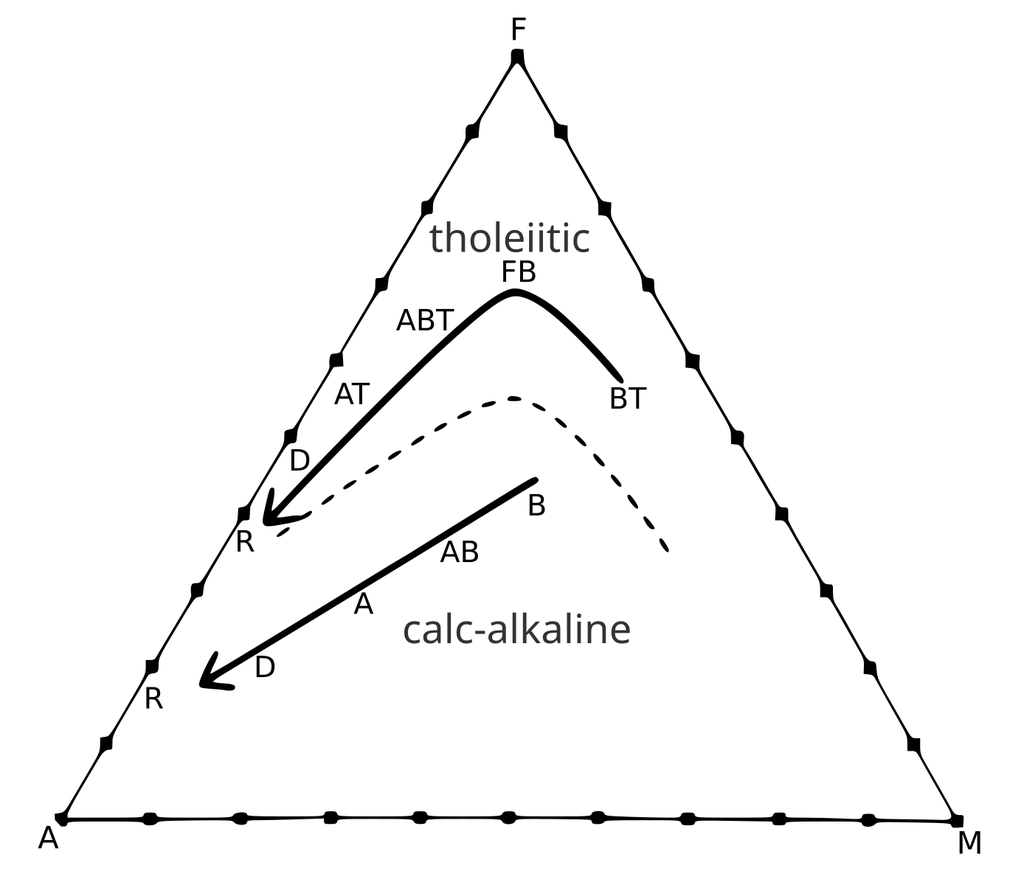

The AFM diagram, a ternary diagram between the Alkali, Fe, and Mg oxides used to distinguish the calc-alkaline magma series from the tholeiitic magma series.  
**Key/Legend:** A – alkali (sodium and potassium) oxides, F – iron oxides, M – magnesium oxide, BT – tholeiitic basalt, FB – ferro-basalt, ABT – tholeiitic basaltic andesite, AT – tholeiitic andesite, D – dacite, R – rhyolite, B – basalt, AB – basaltic andesite, A – andesite; dashed line – boundary between tholeiitic and calc-alkaline compositions.

Source: [Wikimedia Commons](https://commons.wikimedia.org/wiki/File:AFM_diagram_-.svg)

**Interpretation:**  
- **Tholeiitic trend:** Moves from M → F → A (iron enrichment).  
- **Calc-Alkaline trend:** Direct M → A, bypassing strong Fe enrichment.  
- **Alkaline series:** Starts near A corner; higher Na + K content from the start.

# What is the TAS Diagram?

**TAS = Total Alkali vs. Silica Diagram**

> A geochemical classification chart that uses **SiO₂ (wt%)** and **Total Alkalis (Na₂O + K₂O wt%)**  
> to distinguish and name **volcanic rocks** (IUGS 1989).

It is used primarily for:  
- **Chemical classification** of volcanic rocks (especially fine-grained).  
- Differentiating **subalkaline** (tholeiitic + calc-alkaline) and **alkaline** rock series.  
- Comparing magma compositions across tectonic settings.

# Axes and Variables

| Axis | Parameter | Represents |
| --- | --- | --- |
| **X-axis** | SiO₂ (wt%) | Silica content — degree of differentiation |
| **Y-axis** | Na₂O + K₂O (wt%) | Total alkalis — sodium and potassium enrichment |

**Silica increases → differentiation**  
**Alkalis increase → fractionation / partial melting influence**

# Fields on the TAS Diagram

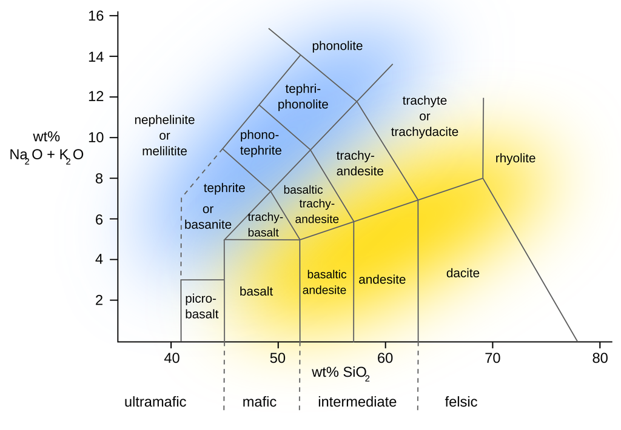

TAS diagram showing chemical composition range of sub-alkaline volcanic rocks including calc-alkaline rocks (yellow area) and alkaline volcanic rocks (blue area).

Source: [Wikipedia](https://en.wikipedia.org/wiki/Calc-alkaline_magma_series#/media/File:Classification_extrusive_rocks_EN.svg)

The TAS diagram contains **named compositional fields** (Le Bas et al., 1986; IUGS, 1989):

[output not shown]

**Dividing Line:**  
- The **Irvine & Baragar (1971)** line separates **Subalkaline** from **Alkaline** magmas.

**Key Points:**  
- The **x-axis** increases with **differentiation (SiO₂)**.  
- The **y-axis** increases with **alkali enrichment (Na₂O + K₂O)**.  
- **Alkaline rocks** plot *above* the dividing line.  
- **Subalkaline rocks** plot *below* the line.

# Subalkaline vs. Alkaline Series

| Feature | **Subalkaline (Tholeiitic + Calc-Alkaline)** | **Alkaline Series** |
| --- | --- | --- |
| Total Alkalis | Low to moderate | High (Na + K enriched) |
| SiO₂ | Moderate to high | Variable |
| Mineralogy | Plagioclase, pyroxene, amphibole | Alkali feldspar, nepheline, leucite |
| Tectonic Setting | Mid-ocean ridges, subduction arcs | Intraplate rifts, hot spots |
| Examples | Andesite, Dacite, Rhyolite | Trachyte, Phonolite |

# Tectonic Associations Summary

| Tectonic Environment | Typical Magma Series | Example Volcanoes |
| --- | --- | --- |
| Mid-ocean ridge | Tholeiitic | Iceland, Atlantic Ridge |
| Island arc / continental arc | Calc-Alkaline | Andes, Japan, Cascades |
| Intraplate / continental rift | Alkaline | East African Rift, Canary Islands |